# Module 1: Single Instrument Pricing

A deep dive into the fixed-rate bond pricing engine. We verify against textbook examples, visualise the price-yield relationship, inspect cash flows, and explore how coupon rate, maturity, and frequency affect bond prices.

```python
# ruff: noqa: E402
import sys
import warnings
from datetime import date, timedelta

sys.path.insert(0, "..")
warnings.filterwarnings("ignore")

import matplotlib.pyplot as plt
import numpy as np

from src.instruments.bond import Bond
from src.instruments.pricing import price
from src.instruments.ytm_solver import ytm_solver

TOLERANCE = 1e-6


def price_diff(bond: Bond, target_price: float, y: float) -> float:
    return price(bond, y) - target_price


def dv01_approx(bond: Bond, y: float, eps: float = 1e-6) -> float:
    return (price(bond, y + eps) - price(bond, y - eps)) / (2 * eps)


from src.utils.plotting import set_theme

set_theme()
print("All imports OK — ready to explore.")
```

```
All imports OK — ready to explore.
```

## 1. Bond Anatomy

A `Bond` is the fundamental instrument. Let's inspect its properties.

```python
b = Bond(face_value=100, coupon_rate=0.05, maturity=3.0, freq=2)
print(f"{b!r}\n")
print(f"  Face value:       {b.face_value}")
print(f"  Coupon rate:      {b.coupon_rate * 100:.2f}%")
print(f"  Maturity:         {b.maturity} years")
print(f"  Frequency:        {b.freq} x / year")
print(f"  Total periods:    {b.periods}  (= maturity × freq)")
print(f"  Coupon payment:   {b.coupon_payment}  (= face × coupon / freq)")
```

```
Bond(face_value=100, coupon_rate=0.05, maturity=3.0, freq=2)

  Face value:       100
  Coupon rate:      5.00%
  Maturity:         3.0 years
  Frequency:        2 x / year
  Total periods:    6  (= maturity × freq)
  Coupon payment:   2.5  (= face × coupon / freq)
```

### Validation

The `Bond` rejects nonsensical inputs at construction time.

```python
bad_cases = [
    ("negative face", lambda: Bond(-100, 0.05, 3.0)),
    ("negative coupon", lambda: Bond(100, -0.01, 3.0)),
    ("zero maturity", lambda: Bond(100, 0.05, 0)),
    ("invalid freq (3)", lambda: Bond(100, 0.05, 3.0, freq=3)),
    ("invalid freq (0)", lambda: Bond(100, 0.05, 3.0, freq=0)),
]

for label, case in bad_cases:
    try:
        case()
        print(f"  ✗ {label}: should have raised!")
    except ValueError as e:
        print(f"  ✓ {label}: {e}")
```

```
  ✓ negative face: face_value must be positive
  ✓ negative coupon: coupon_rate must be non-negative
  ✓ zero maturity: maturity must be positive
  ✓ invalid freq (3): freq must be 1, 2, 4, or 12
  ✓ invalid freq (0): freq must be 1, 2, 4, or 12
```

## 2. Pricing Formula

The price of a fixed-rate bond is the sum of the present values of all future cash flows:

$$ P = \sum_{t=1}^{T \times m} \frac{F \cdot C \,/\, m}{(1 + y \,/\, m)^t} + \frac{F}{(1 + y \,/\, m)^{T \times m}} $$

The first term sums the present values of all coupon payments, while the second term is the present value of the face value (principal) returned at maturity. Each cash flow is discounted by the per-period yield $y/m$, raised to the power of the number of periods until that cash flow is received.

| Symbol | Meaning |
| --- | --- |
| $F$ | Face value (principal) |
| $C$ | Annual coupon rate as a decimal (e.g. 0.05 for 5%) |
| $F \cdot C / m$ | Dollar coupon payment per period |
| $T$ | Years to maturity |
| $m$ | Coupon payments per year |
| $y$ | Market yield (YTM, decimal) |

Let's unpack this by looking at the individual cash flows.

```python
def cash_flow_schedule(bond: Bond, yield_rate: float):
    """Return array of periods, cash flows, discount factors, and PV."""
    r = yield_rate / bond.freq
    t = np.arange(1, bond.periods + 1)
    cf = np.full(bond.periods, bond.coupon_payment)
    cf[-1] += bond.face_value  # final payment includes principal
    df = (1 + r) ** -t  # discount factors
    pv = cf * df
    return t, cf, df, pv


b = Bond(100, 0.05, 3.0, 2)
t, cf, df, pv = cash_flow_schedule(b, 0.04)

print(f"Bond: 3-year, 5% semi-annual, yield = 4%  |  Price = {pv.sum():.6f}\n")
print("  Period   Cash Flow   Discount Factor   Present Value")
print("  ------   ---------   ---------------   -------------")
for i in range(len(t)):
    print(f"  {t[i]:>5.0f}   {cf[i]:>9.2f}   {df[i]:>15.6f}   {pv[i]:>13.6f}")
print(f"  {'':->50}")
print(f"  {'Total':>27}   {pv.sum():>13.6f}")
```

```
Bond: 3-year, 5% semi-annual, yield = 4%  |  Price = 102.800715

  Period   Cash Flow   Discount Factor   Present Value
  ------   ---------   ---------------   -------------
      1        2.50          0.980392        2.450980
      2        2.50          0.961169        2.402922
      3        2.50          0.942322        2.355806
      4        2.50          0.923845        2.309614
      5        2.50          0.905731        2.264327
      6      102.50          0.887971       91.017067
  --------------------------------------------------
                        Total      102.800715
```

### Visualising the Cash Flow Waterfall

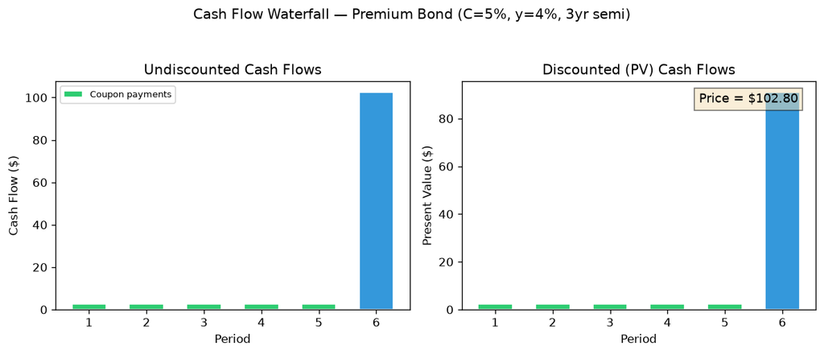

```python
fig, (ax1, ax2) = plt.subplots(1, 2, figsize=(10, 4))

colours = ["#2ecc71"] * (len(t) - 1) + ["#3498db"]

# --- Cash flows (undiscounted) ---
ax1.bar(t, cf, color=colours, edgecolor="white", width=0.6)
ax1.set_xlabel("Period")
ax1.set_ylabel("Cash Flow ($)")
ax1.set_title("Undiscounted Cash Flows")
ax1.set_xticks(t)
ax1.legend(["Coupon payments", "Face value at maturity"], fontsize=8)

# --- PV contribution per period ---
ax2.bar(t, pv, color=colours, edgecolor="white", width=0.6)
ax2.set_xlabel("Period")
ax2.set_ylabel("Present Value ($)")
ax2.set_title("Discounted (PV) Cash Flows")
ax2.set_xticks(t)
total = pv.sum()
ax2.text(
    0.95,
    0.95,
    f"Price = ${total:.2f}",
    ha="right",
    va="top",
    transform=ax2.transAxes,
    fontsize=11,
    bbox=dict(facecolor="wheat", alpha=0.5),
)

fig.suptitle("Cash Flow Waterfall — Premium Bond (C=5%, y=4%, 3yr semi)", y=1.05)
plt.tight_layout()
plt.show()
```

## 3. Price-Yield Relationship

Bond prices and yields move in **opposite directions** (inverse relationship) because the discount factor $1/(1+y/m)^t$ increases as $y$ decreases.

The relationship is **convex** — not linear. This convexity is what Module 2 (Duration & Convexity) will quantify.

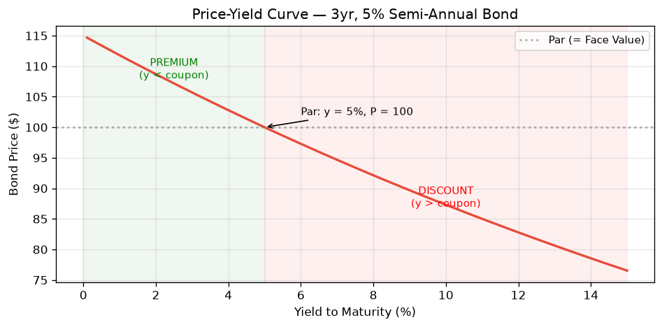

```
At y=2%:  P = $108.6932   (well above par)
At y=5%:  P = $100.0000   (at par)
At y=8%:  P = $92.1368   (well below par)
```

```python
b = Bond(100, 0.05, 3.0, 2)
yields = np.linspace(0.001, 0.15, 300)
prices = np.array([price(b, y) for y in yields])

fig, ax = plt.subplots(figsize=(8, 4))
ax.plot(yields * 100, prices, linewidth=2, color="#e74c3c")
ax.axhline(100, color="gray", ls=":", alpha=0.6, label="Par (= Face Value)")

# Annotate par / premium / discount zones
ax.axvspan(0, 5, alpha=0.06, color="green", label="_nolegend_")
ax.axvspan(5, 15, alpha=0.06, color="red", label="_nolegend_")
ax.text(2.5, 108, "PREMIUM\n(y < coupon)", ha="center", fontsize=9, color="green")
ax.text(10, 87, "DISCOUNT\n(y > coupon)", ha="center", fontsize=9, color="red")
ax.annotate(
    "Par: y = 5%, P = 100",
    xy=(5, 100),
    xytext=(6, 102),
    arrowprops=dict(arrowstyle="->"),
    fontsize=9,
)

ax.set_xlabel("Yield to Maturity (%)")
ax.set_ylabel("Bond Price ($)")
ax.set_title("Price-Yield Curve — 3yr, 5% Semi-Annual Bond")
ax.legend(fontsize=9)
ax.grid(alpha=0.3)
plt.tight_layout()
plt.show()

print(f"At y=2%:  P = ${price(b, 0.02):.4f}   (well above par)")
print(f"At y=5%:  P = ${price(b, 0.05):.4f}   (at par)")
print(f"At y=8%:  P = ${price(b, 0.08):.4f}   (well below par)")
```

### Impact of Coupon Rate

Higher-coupon bonds are less sensitive to yield changes because more cash flow is received early. This shifts the **weighted-average timing** of cash flows closer to the present, effectively reducing the bond's *Macaulay Duration* — a concept we will formally define and implement in Module 2.

Intuitively: if you receive a larger fraction of your total return as early coupon payments, the far-future face value (which is most affected by rate changes) contributes less to the overall price, making the bond less volatile.

Let's overlay bonds with different coupons to see this in action.

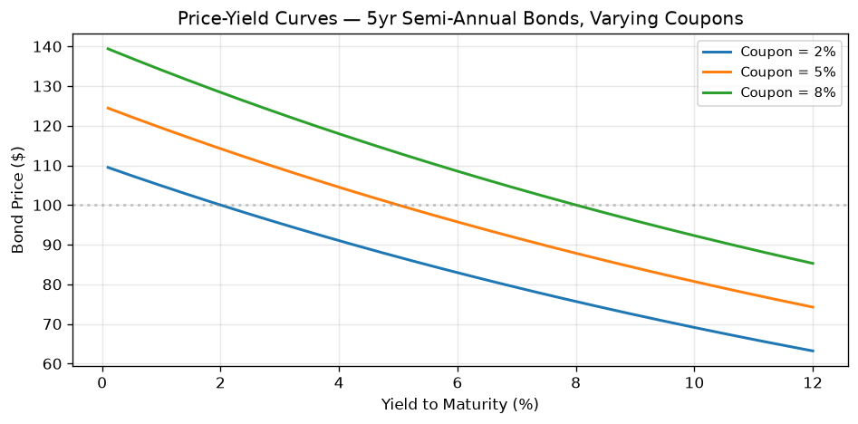

```python
fig, ax = plt.subplots(figsize=(8, 4))
yields = np.linspace(0.001, 0.12, 300)

for coupon in [0.02, 0.05, 0.08]:
    b = Bond(100, coupon, 5.0, 2)
    prices = [price(b, y) for y in yields]
    ax.plot(yields * 100, prices, label=f"Coupon = {coupon * 100:.0f}%", linewidth=1.8)

ax.axhline(100, color="gray", ls=":", alpha=0.4)
ax.set_xlabel("Yield to Maturity (%)")
ax.set_ylabel("Bond Price ($)")
ax.set_title("Price-Yield Curves — 5yr Semi-Annual Bonds, Varying Coupons")
ax.legend(fontsize=9)
ax.grid(alpha=0.3)
plt.tight_layout()
plt.show()
```

### Price vs Coupon Rate at Fixed Yield

Flipping the axes: fix the yield and vary the coupon rate. The relationship is **linear** — each 1% increase in coupon adds the same PV increment regardless of the current coupon level. The slope depends on the yield: lower yields (higher discount factors) amplify the price impact of a given coupon change.

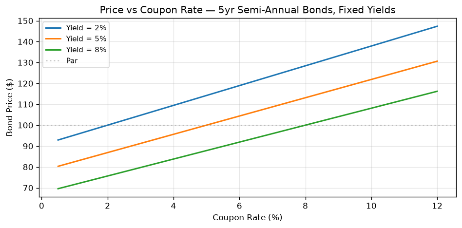

```python
fig, ax = plt.subplots(figsize=(8, 4))
coupons = np.linspace(0.005, 0.12, 200)
maturity = 5.0

for y_fixed in [0.02, 0.05, 0.08]:
    prices = []
    for c in coupons:
        b = Bond(100, c, maturity, 2)
        prices.append(price(b, y_fixed))
    ax.plot(coupons * 100, prices, label=f"Yield = {y_fixed * 100:.0f}%", linewidth=1.8)

ax.axhline(100, color="gray", ls=":", alpha=0.4, label="Par")
ax.set_xlabel("Coupon Rate (%)")
ax.set_ylabel("Bond Price ($)")
ax.set_title("Price vs Coupon Rate — 5yr Semi-Annual Bonds, Fixed Yields")
ax.legend(fontsize=9)
ax.grid(alpha=0.3)
plt.tight_layout()
plt.show()
```

### Impact of Time to Maturity

Longer maturities amplify price sensitivity (more periods to discount).

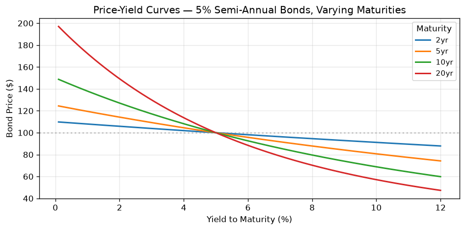

```python
fig, ax = plt.subplots(figsize=(8, 4))

for maturity in [2, 5, 10, 20]:
    b = Bond(100, 0.05, float(maturity), 2)
    prices = [price(b, y) for y in yields]
    ax.plot(yields * 100, prices, label=f"{maturity}yr", linewidth=1.8)

ax.axhline(100, color="gray", ls=":", alpha=0.4)
ax.set_xlabel("Yield to Maturity (%)")
ax.set_ylabel("Bond Price ($)")
ax.set_title("Price-Yield Curves — 5% Semi-Annual Bonds, Varying Maturities")
ax.legend(fontsize=9, title="Maturity")
ax.grid(alpha=0.3)
plt.tight_layout()
plt.show()
```

## 4. Accrued Interest & Settlement Pricing

The `price()` function prices the bond as-of a coupon payment date (no accrued interest). In real markets, bonds trade between coupon dates. The **dirty price** (full invoice amount) includes accrued interest earned by the seller since the last coupon. The **clean price** (quoted price) is the dirty price minus accrued interest.

$$ \text{AI} = \text{Coupon Payment} \times \frac{\text{Days Since Last Coupon}}{\text{Days in Coupon Period}} $$

$$ \text{Dirty Price} = \text{PV of remaining cash flows} \qquad \text{Clean Price} = \text{Dirty Price} - \text{AI} $$

```python
def accrued_interest(
    coupon_payment: float, days_since_last: int, days_in_period: int
) -> float:
    """Accrued interest since the last coupon payment."""
    return coupon_payment * days_since_last / days_in_period


def days_between(start: date, end: date) -> int:
    """Return the number of calendar days between two dates."""
    return (end - start).days


def dirty_price(
    bond: Bond,
    yield_rate: float,
    settlement: date,
    last_coupon: date,
    next_coupon: date,
) -> float:
    """Full invoice price including accrued interest."""
    days_in_period = days_between(last_coupon, next_coupon)
    days_since_last = days_between(last_coupon, settlement)
    frac = days_since_last / days_in_period
    # PV of remaining cash flows from settlement
    rate_per_period = yield_rate / bond.freq
    t = np.arange(1, bond.periods + 1)
    # Adjust: first coupon is partially earned — discount from next coupon date
    cf = np.full(bond.periods, bond.coupon_payment)
    cf[-1] += bond.face_value
    pv = np.sum(cf / (1 + rate_per_period) ** (t - frac))
    return float(pv)


def clean_price(
    bond: Bond,
    yield_rate: float,
    settlement: date,
    last_coupon: date,
    next_coupon: date,
) -> float:
    """Quoted price (dirty price minus accrued interest)."""
    days_in_period = days_between(last_coupon, next_coupon)
    days_since_last = days_between(last_coupon, settlement)
    ai = accrued_interest(bond.coupon_payment, days_since_last, days_in_period)
    dp = dirty_price(bond, yield_rate, settlement, last_coupon, next_coupon)
    return dp - ai


# Concrete example
b5 = Bond(100, 0.05, 3.0, 2)  # 3yr, 5% semi-annual
# Assume: last coupon Jan 1 2026, next coupon Jul 1 2026
last_coupon = date(2026, 1, 1)
next_coupon = date(2026, 7, 1)
days_in_period = days_between(last_coupon, next_coupon)

print("Bond: 3yr, 5% semi-annual, yield = 4%")
print(f"Coupon period: {last_coupon} to {next_coupon} ({days_in_period} days)\n")
print(
    f"{'Settlement':<14} {'Days Since':>10} "
    f"{'Accrued':>10} {'Dirty Price':>12} {'Clean Price':>12}"
)
print("-" * 60)

for day in [15, 60, 120, 150, 180]:
    sett = last_coupon + timedelta(days=day)
    dsml = days_between(last_coupon, sett)
    ai = accrued_interest(b5.coupon_payment, dsml, days_in_period)
    dp = dirty_price(b5, 0.04, sett, last_coupon, next_coupon)
    cp = clean_price(b5, 0.04, sett, last_coupon, next_coupon)
    print(f"{sett:<14} {dsml:>10} {ai:>10.4f} {dp:>12.6f} {cp:>12.6f}")
```

```
Bond: 3yr, 5% semi-annual, yield = 4%
Coupon period: 2026-01-01 to 2026-07-01 (181 days)

Settlement     Days Since    Accrued  Dirty Price  Clean Price
------------------------------------------------------------
<14         15     0.2072   102.969560   102.762378
<14         60     0.8287   103.477761   102.649032
<14        120     1.6575   104.159265   102.501807
<14        150     2.0718   104.501699   102.429876
<14        180     2.4862   104.845258   102.359070
```

### 4.2 Day Count Conventions

Different markets use different day count conventions to calculate the fraction of the coupon period that has elapsed:

| Convention | Formula | Used In |
| --- | --- | --- |
| **30/360** | Days = 360 × (Y₂−Y₁) + 30 × (M₂−M₁) + (D₂−D₁), adjusting D≥31 → 30 | US corporate bonds |
| **Act/Act** | Actual days / Actual days in year (or period) | US Treasuries, government bonds |
| **Act/360** | Actual days / 360 | Money markets, short-term instruments |
| **Act/365** | Actual days / 365 | UK gilts, some corporate bonds |

The choice of convention changes the accrued interest and therefore the clean price, especially for settlement dates far from the coupon payment dates.

```python
def dcf_30_360(start: date, end: date) -> float:
    """Day count fraction using 30/360 (US NASD) convention."""
    """Day count fraction using 30/360 (US NASD) convention."""
    d1 = min(start.day, 30)
    d2 = 30 if end.day == 31 and d1 >= 30 else end.day
    return (
        360 * (end.year - start.year) + 30 * (end.month - start.month) + (d2 - d1)
    ) / 360


def dcf_act_act(start: date, end: date) -> float:
    """Day count fraction using Act/Act (ISDA) convention."""
    return (end - start).days / 365


def dcf_act_360(start: date, end: date) -> float:
    """Day count fraction using Act/360 convention."""
    return (end - start).days / 360


def dcf_act_365(start: date, end: date) -> float:
    """Day count fraction using Act/365 convention."""
    return (end - start).days / 365


# Compare conventions for the same bond/settlement
last_coupon = date(2026, 1, 1)
settlement = date(2026, 4, 20)  # mid-period
next_coupon = date(2026, 7, 1)

conventions = [
    ("30/360", dcf_30_360),
    ("Act/Act", dcf_act_act),
    ("Act/360", dcf_act_360),
    ("Act/365", dcf_act_365),
]

cp = b5.coupon_payment
print(f"Bond: 3yr, 5% semi-annual, coupon payment = ${cp:.2f}")
print(
    f"Last coupon: {last_coupon}   "
    f"Settlement: {settlement}   "
    f"Next coupon: {next_coupon}\n"
)
print(f"{'Convention':<12} {'Fraction':>10} {'Accrued Interest':>18}")
print("-" * 42)
for name, fn in conventions:
    frac = fn(last_coupon, settlement)
    ai = cp * frac
    print(f"{name:<12} {frac:>10.6f} {ai:>18.4f}")
```

```
Bond: 3yr, 5% semi-annual, coupon payment = $2.50
Last coupon: 2026-01-01   Settlement: 2026-04-20   Next coupon: 2026-07-01

Convention     Fraction   Accrued Interest
------------------------------------------
30/360         0.302778             0.7569
Act/Act        0.298630             0.7466
Act/360        0.302778             0.7569
Act/365        0.298630             0.7466
```

## 4. Textbook Verification Cases

The canonical three scenarios: **par**, **premium**, and **discount**.

```python
b3 = Bond(100, 0.05, 3.0, 2)

cases = [
    ("Par", 0.05, 100.00, 0.05),
    ("Premium", 0.04, 102.80, 0.04),
    ("Discount", 0.06, 97.29, 0.06),
]

print(
    f"{'Case':<10} {'Yield':>6} {'Price':>10} {'YTM':>8} {'Price OK?':<10} {'YTM OK?'}"
)
print("-" * 60)
for label, y_in, expected_p, expected_y in cases:
    p = price(b3, y_in)
    y = ytm_solver(b3, p)
    p_ok = abs(p - expected_p) < 0.02
    y_ok = abs(y - expected_y) < 0.0002
    print(
        f"{label:<10} {y_in * 100:>5.1f}% {p:>10.4f} {y * 100:>7.4f}% "
        f"{'✓' if p_ok else '✗':<10} {'✓' if y_ok else '✗'}"
    )
```

```
Case        Yield      Price      YTM Price OK?  YTM OK?
------------------------------------------------------------
Par          5.0%   100.0000  5.0000% ✓          ✓
Premium      4.0%   102.8007  4.0000% ✓          ✓
Discount     6.0%    97.2914  6.0000% ✓          ✓
```

### Zero-Coupon Bond

A zero-coupon bond makes no interim payments — just a single lump sum at maturity. Its price is simply the face value discounted back:

$$P = \frac{F}{(1 + y)^T}$$

```
Zero-Coupon Bond: FV=100, T=5yr, y=3%
  Price     = 86.260878
  Expected  = 86.260878
  YTM       = 3.0000%
```

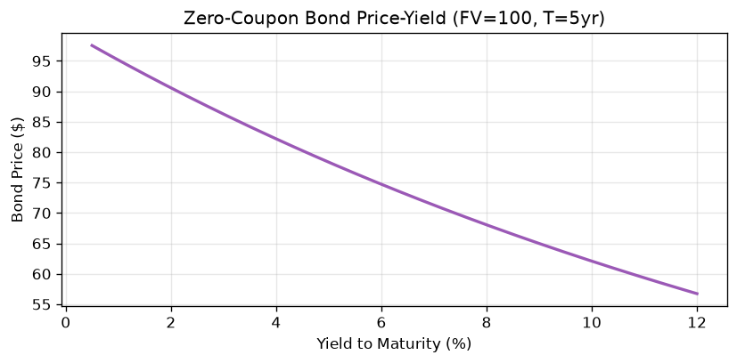

```python
zcb = Bond(100, 0.0, 5.0, 1)
p_zcb = price(zcb, 0.03)
expected_zcb = 100 / (1.03**5)
y_zcb = ytm_solver(zcb, p_zcb)

print("Zero-Coupon Bond: FV=100, T=5yr, y=3%")
print(f"  Price     = {p_zcb:.6f}")
print(f"  Expected  = {expected_zcb:.6f}")
print(f"  YTM       = {y_zcb * 100:.4f}%")
print()

# Show the pure discount relationship across yields
yields_z = np.linspace(0.005, 0.12, 200)
prices_z = np.array([price(zcb, y) for y in yields_z])

fig, ax = plt.subplots(figsize=(7, 3.5))
ax.plot(yields_z * 100, prices_z, color="#9b59b6", linewidth=2)
ax.set_xlabel("Yield to Maturity (%)")
ax.set_ylabel("Bond Price ($)")
ax.set_title("Zero-Coupon Bond Price-Yield (FV=100, T=5yr)")
ax.grid(alpha=0.3)
plt.tight_layout()
plt.show()
```

### Periodic vs Continuous Compounding

Bonds are conventionally priced with **periodic compounding**, discounting each cash flow by $(1 + y/m)^{-t}$. An alternative is **continuous compounding**, where the discount factor is $e^{-y t}$:

$$ P_{\text{cont}} = \sum_{t=1}^{T \cdot m} C_{\text{period}} \cdot e^{-y \cdot t_p} + F \cdot e^{-y \cdot T} $$

where $t_p$ is the time in years to each cash flow and $C_{\text{period}}$ is the per-period coupon.

At the same *nominal* annual yield $y$, the two conventions give *different* prices: continuous compounding applies a higher effective discount rate ($e^y - 1 > y$ for $y > 0$), producing a lower present value. This contrasts with the effect of increasing coupon frequency (earlier cash flows increase price), which dominates at typical coupon levels.

```python
def price_continuous(bond: Bond, yield_rate: float) -> float:
    """Bond price under continuous compounding."""
    r = yield_rate
    t = np.arange(1, bond.periods + 1) / bond.freq  # time in years
    pv_coupons = np.sum(bond.coupon_payment * np.exp(-r * t))
    pv_face = bond.face_value * np.exp(-r * bond.maturity)
    return float(pv_coupons + pv_face)


b = Bond(100, 0.05, 5.0, 2)
y = 0.04
p_cont = price_continuous(b, y)

freqs = [1, 2, 4, 12]
labels = ["Annual", "Semi-Annual", "Quarterly", "Monthly"]

print("Bond: 5yr, 5%, yield = 4%")
print(f"{'Frequency':<14} {'Price':>10} {'Diff from Continuous':>22}")
print("-" * 48)

for freq, label in zip(freqs, labels, strict=True):
    bf = Bond(100, 0.05, 5.0, freq)
    p = price(bf, y)
    print(f"{label:<14} {p:>10.6f} {p - p_cont:>+20.6f}")

print(f"{'Continuous':<14} {p_cont:>10.6f} {'---':>20}")
```

```
Bond: 5yr, 5%, yield = 4%
Frequency           Price   Diff from Continuous
------------------------------------------------
Annual         104.451822            +0.145922
Semi-Annual    104.491293            +0.185393
Quarterly      104.511388            +0.205488
Monthly        104.524922            +0.219023
Continuous     104.305900                  ---
```

## 6. Yield Measures Comparison

Three common yield measures are used to assess a bond's return:

- **Coupon Rate**: $C$ — the stated annual interest rate on the bond's face value.
- **Current Yield**: $\text{Annual Coupon} \, / \, \text{Clean Price}$ — the income return ignoring capital gains/losses.
- **Yield to Maturity (YTM)**: $y$ — the total return assuming the bond is held to maturity.

For a **par** bond (price = face value), all three are equal. For **premium** bonds (price > face): Coupon Rate > Current Yield > YTM. For **discount** bonds (price < face): Coupon Rate < Current Yield < YTM.

The spread between Coupon Rate and Current Yield reflects the capital loss/gain embedded in the price. The spread between Current Yield and YTM reflects the time value of that capital gain/loss (the Pull-to-Par effect).

```python
def current_yield(bond: Bond, clean_price: float) -> float:
    """Return the current yield: annual coupon / clean price."""
    return bond.face_value * bond.coupon_rate / clean_price


cases = [
    ("Discount", Bond(100, 0.03, 5.0, 2), 92.0),
    ("Par", Bond(100, 0.05, 5.0, 2), 100.0),
    ("Premium", Bond(100, 0.07, 5.0, 2), 108.5),
]

print(
    f"{'Case':<12} {'Coupon':>8} {'Price':>8} "
    f"{'Cur. Yld':>8} {'YTM':>8} {'Ordering':>30}"
)
print("-" * 70)
for label, b, p in cases:
    cy = current_yield(b, p)
    ytm = ytm_solver(b, p)
    cr = b.coupon_rate
    if abs(cr - cy) < 1e-10 and abs(cy - ytm) < 1e-10:
        order = "Coupon = Cur Yield = YTM"
    elif cr > max(cy, ytm):
        order = "Coupon > Cur Yield > YTM"
    else:
        order = "Coupon < Cur Yield < YTM"
    print(
        f"{label:<12} {cr * 100:>7.2f}% {p:>8.2f} "
        f"{cy * 100:>7.4f}% {ytm * 100:>7.4f}% {order:>30}"
    )
```

```
Case           Coupon    Price Cur. Yld      YTM                       Ordering
----------------------------------------------------------------------
Discount        3.00%    92.00  3.2609%  4.8196%       Coupon < Cur Yield < YTM
Par             5.00%   100.00  5.0000%  5.0000%       Coupon = Cur Yield = YTM
Premium         7.00%   108.50  6.4516%  5.0548%       Coupon > Cur Yield > YTM
```

### Different Coupon Frequencies

Increasing the coupon frequency while holding the *nominal* annual yield constant produces a small price increase. Two effects are at work:

1. **Coupon timing**: More frequent payments mean coupons arrive earlier. Earlier cash flows are discounted less, increasing their present value.
2. **Compounding effect**: The per-period discount rate drops to $y/m$, but there are $m$ times as many periods. The *effective annual rate* $(1 + y/m)^m - 1$ actually **increases** with $m$, which, in isolation, would *decrease* the price.

For coupon-bearing bonds, effect (1) dominates effect (2), producing the slight net price increase shown below. Notice that each successive increment (annual → semi → quarterly → monthly) is progressively smaller, consistent with convergence toward continuous compounding.

```python
freqs = [1, 2, 4, 12]
labels = ["Annual", "Semi-Annual", "Quarterly", "Monthly"]

print(f"{'Frequency':<14} {'Price':>10} {'Diff from Annual':>18}")
print("-" * 45)

p_annual = None
for freq, label in zip(freqs, labels, strict=True):
    b = Bond(100, 0.06, 5.0, freq)
    p = price(b, 0.05)
    diff = p - (p_annual or p)
    if p_annual is None:
        p_annual = p
    print(f"{label:<14} {p:>10.4f} {diff:>+17.6f}")
```

```
Frequency           Price   Diff from Annual
---------------------------------------------
Annual           104.3295         +0.000000
Semi-Annual      104.3760         +0.046555
Quarterly        104.3998         +0.070352
Monthly          104.4159         +0.086416
```

## 5. YTM Solver: How the Root-Finding Works

The YTM equation cannot be algebraically inverted, so we use numerical methods.

### Newton-Raphson

Iteratively refines the estimate using the derivative of price w.r.t. yield:

$$y_{n+1} = y_n - \frac{P(y_n) - P_{\text{target}}}{P'(y_n)}$$

Newton-Raphson has **quadratic convergence**: the error roughly *squares* on each iteration ($|e_{n+1}| \propto |e_n|^2$). This is why the solver typically converges in just 3–5 iterations.

The derivative $P'(y)$ is computed numerically using a **central difference** approximation:

$$P'(y) \approx \frac{P(y + \varepsilon) - P(y - \varepsilon)}{2\varepsilon}$$

This is an $O(\varepsilon^2)$ approximation, implemented in `_dv01_approx()` with $\varepsilon = 10^{-6}$.

### Bisection (fallback)

Bisection is used as a fallback because Newton-Raphson can fail when:

- The initial guess is far from the root.
- The derivative is near zero (flat price-yield region).
- The function has inflection points causing oscillation.

Bisection **guarantees convergence** as long as the root is bracketed (the function changes sign across the interval).

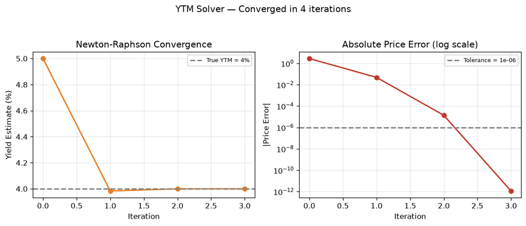

```
Final YTM: 4.000000%
True YTM:  4.00%
```

```python
def trace_newton(bond, target_price, guess=0.05):
    """Trace Newton-Raphson YTM solver iterations."""
    y = guess
    trace = []
    for _ in range(50):
        p = price(bond, y)
        f = p - target_price
        trace.append((y, p, f))
        if abs(f) < TOLERANCE:
            break
        derivative = dv01_approx(bond, y)
        if abs(derivative) < 1e-12:
            break
        y -= f / derivative
    return np.array(trace)


b = Bond(100, 0.05, 3.0, 2)
target = price(b, 0.04)  # premium bond, true YTM = 4%
trace = trace_newton(b, target)

fig, (ax1, ax2) = plt.subplots(1, 2, figsize=(10, 4))

iters = np.arange(len(trace))

# Left: yield estimate per iteration
ax1.plot(iters, trace[:, 0] * 100, "o-", color="#e67e22")
ax1.axhline(4.0, color="gray", ls="--", label="True YTM = 4%")
ax1.set_xlabel("Iteration")
ax1.set_ylabel("Yield Estimate (%)")
ax1.set_title("Newton-Raphson Convergence")
ax1.legend(fontsize=8)
ax1.grid(alpha=0.3)

# Right: price error per iteration
ax2.plot(iters, np.abs(trace[:, 2]), "o-", color="#c0392b")
ax2.axhline(TOLERANCE, color="gray", ls="--", label=f"Tolerance = {TOLERANCE}")
ax2.set_xlabel("Iteration")
ax2.set_ylabel("|Price Error|")
ax2.set_yscale("log")
ax2.set_title("Absolute Price Error (log scale)")
ax2.legend(fontsize=8)
ax2.grid(alpha=0.3)

plt.suptitle(f"YTM Solver — Converged in {len(trace)} iterations", y=1.05)
plt.tight_layout()
plt.show()

print(f"Final YTM: {trace[-1, 0] * 100:.6f}%")
print(f"True YTM:  {0.04 * 100:.2f}%")
```

### Comparison: Newton-Raphson vs Bisection Convergence Speed

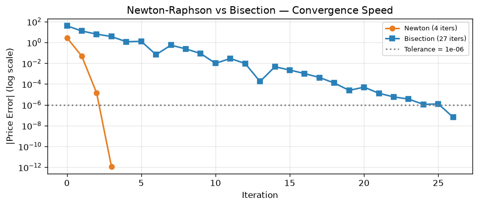

```python
def trace_bisection(bond, target_price, low=-0.05, high=0.50):
    """Trace bisection YTM solver iterations."""
    trace = []
    for _ in range(200):
        mid = (low + high) / 2
        f_mid = price_diff(bond, target_price, mid)
        trace.append((mid, f_mid))
        if abs(f_mid) < TOLERANCE:
            break
        f_low = price_diff(bond, target_price, low)
        if f_low * f_mid <= 0:
            high = mid
        else:
            low = mid
    return np.array(trace)


b = Bond(100, 0.05, 3.0, 2)
target = price(b, 0.04)

trace_n = trace_newton(b, target)
trace_b = trace_bisection(b, target)

fig, ax = plt.subplots(figsize=(8, 3.5))

n_iters = np.arange(len(trace_n))
b_iters = np.arange(len(trace_b))

ax.semilogy(
    n_iters,
    np.abs(trace_n[:, 2]),
    "o-",
    label=f"Newton ({len(trace_n)} iters)",
    color="#e67e22",
)
ax.semilogy(
    b_iters,
    np.abs(trace_b[:, 1]),
    "s-",
    label=f"Bisection ({len(trace_b)} iters)",
    color="#2980b9",
)
ax.axhline(TOLERANCE, color="gray", ls=":", label=f"Tolerance = {TOLERANCE}")

ax.set_xlabel("Iteration")
ax.set_ylabel("|Price Error| (log scale)")
ax.set_title("Newton-Raphson vs Bisection — Convergence Speed")
ax.legend(fontsize=8)
ax.grid(alpha=0.3)
plt.tight_layout()
plt.show()
```

### DV01 — Dollar Value of 1 Basis Point

**DV01** (also called PV01 or Dollar Duration) measures the change in a bond's price for a 1 basis point (0.01%) change in yield:

$$ \text{DV01}(y) = -\frac{dP}{dy} \times 0.0001 $$

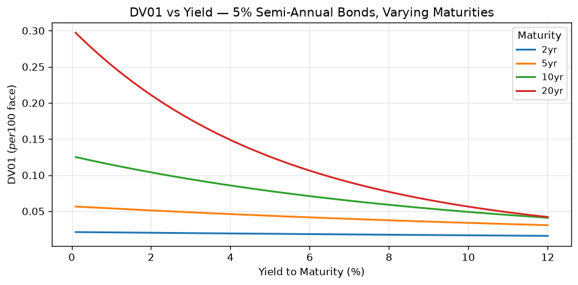

```python
fig, ax = plt.subplots(figsize=(8, 4))
yields = np.linspace(0.001, 0.12, 200)

for maturity in [2, 5, 10, 20]:
    b = Bond(100, 0.05, float(maturity), 2)
    dv01s = [abs(dv01_approx(b, y)) * 0.0001 for y in yields]
    ax.plot(yields * 100, dv01s, label=f"{maturity}yr", linewidth=1.8)

ax.set_xlabel("Yield to Maturity (%)")
ax.set_ylabel("DV01 ($ per $100 face)")
ax.set_title("DV01 vs Yield — 5% Semi-Annual Bonds, Varying Maturities")
ax.legend(fontsize=9, title="Maturity")
ax.grid(alpha=0.3)
plt.tight_layout()
plt.show()
```

## 6. Round-Trip Sanity Check

For any bond and any yield, `ytm_solver(price(bond, y))` should recover `y`.

```python
import itertools

test_bonds = [
    Bond(100, 0.05, 3.0, 2),
    Bond(100, 0.03, 5.0, 1),
    Bond(1000, 0.04, 10.0, 2),
    Bond(100, 0.06, 2.0, 4),
    Bond(100, 0.0, 5.0, 1),
    Bond(100, 0.08, 7.0, 12),
]

test_yields = [0.02, 0.04, 0.05, 0.06, 0.08]

print(
    f"{'Bond':<36} {'Input Yld':>10} {'Price':>10} {'Recovered Yld':>14} {'Error':>12}"
)
print("-" * 85)

max_err = 0.0
for bond, y_in in itertools.product(test_bonds, test_yields):
    p = price(bond, y_in)
    y_out = ytm_solver(bond, p)
    err = abs(y_out - y_in)
    max_err = max(max_err, err)
    desc = (
        f"F={bond.face_value} C={bond.coupon_rate * 100:.0f}% "
        f"T={bond.maturity}yr m={bond.freq}"
    )
    passed = err < 1e-5
    print(
        f"{desc:<36} {y_in * 100:>9.2f}% {p:>10.4f} "
        f"{y_out * 100:>12.6f}% {'✓' if passed else '✗':>8} "
        f"(err={err:.2e})"
    )

print(f"\nMax round-trip error: {max_err:.2e}  (tolerance = {TOLERANCE})")
```

```
Bond                                  Input Yld      Price  Recovered Yld        Error
-------------------------------------------------------------------------------------
F=100 C=5% T=3.0yr m=2                    2.00%   108.6932     2.000000%        ✓ (err=2.93e-11)
F=100 C=5% T=3.0yr m=2                    4.00%   102.8007     4.000000%        ✓ (err=4.02e-15)
F=100 C=5% T=3.0yr m=2                    5.00%   100.0000     5.000000%        ✓ (err=0.00e+00)
F=100 C=5% T=3.0yr m=2                    6.00%    97.2914     6.000000%        ✓ (err=3.31e-15)
F=100 C=5% T=3.0yr m=2                    8.00%    92.1368     8.000000%        ✓ (err=1.96e-11)
F=100 C=3% T=5.0yr m=1                    2.00%   104.7135     2.000000%        ✓ (err=1.26e-09)
F=100 C=3% T=5.0yr m=1                    4.00%    95.5482     4.000000%        ✓ (err=1.51e-13)
F=100 C=3% T=5.0yr m=1                    5.00%    91.3410     5.000000%        ✓ (err=0.00e+00)
F=100 C=3% T=5.0yr m=1                    6.00%    87.3629     6.000000%        ✓ (err=1.19e-13)
F=100 C=3% T=5.0yr m=1                    8.00%    80.0364     8.000000%        ✓ (err=6.20e-10)
F=1000 C=4% T=10.0yr m=2                  2.00%  1180.4555     2.000000%        ✓ (err=1.79e-14)
F=1000 C=4% T=10.0yr m=2                  4.00%  1000.0000     4.000000%        ✓ (err=6.77e-12)
F=1000 C=4% T=10.0yr m=2                  5.00%   922.0542     5.000000%        ✓ (err=0.00e+00)
F=1000 C=4% T=10.0yr m=2                  6.00%   851.2253     6.000000%        ✓ (err=4.89e-12)
F=1000 C=4% T=10.0yr m=2                  8.00%   728.1935     8.000000%        ✓ (err=2.36e-15)
F=100 C=6% T=2.0yr m=4                    2.00%   107.8230     2.000000%        ✓ (err=1.37e-12)
F=100 C=6% T=2.0yr m=4                    4.00%   103.8258     4.000000%        ✓ (err=5.62e-16)
F=100 C=6% T=2.0yr m=4                    5.00%   101.8920     5.000000%        ✓ (err=0.00e+00)
F=100 C=6% T=2.0yr m=4                    6.00%   100.0000     6.000000%        ✓ (err=4.30e-16)
F=100 C=6% T=2.0yr m=4                    8.00%    96.3373     8.000000%        ✓ (err=1.08e-12)
F=100 C=0% T=5.0yr m=1                    2.00%    90.5731     2.000000%        ✓ (err=1.45e-09)
F=100 C=0% T=5.0yr m=1                    4.00%    82.1927     4.000000%        ✓ (err=1.75e-13)
F=100 C=0% T=5.0yr m=1                    5.00%    78.3526     5.000000%        ✓ (err=0.00e+00)
F=100 C=0% T=5.0yr m=1                    6.00%    74.7258     6.000000%        ✓ (err=1.38e-13)
F=100 C=0% T=5.0yr m=1                    8.00%    68.0583     8.000000%        ✓ (err=7.18e-10)
F=100 C=8% T=7.0yr m=12                   2.00%   139.1621     2.000000%        ✓ (err=6.66e-16)
F=100 C=8% T=7.0yr m=12                   4.00%   124.3864     4.000000%        ✓ (err=4.07e-13)
F=100 C=8% T=7.0yr m=12                   5.00%   117.6880     5.000000%        ✓ (err=0.00e+00)
F=100 C=8% T=7.0yr m=12                   6.00%   111.4088     6.000000%        ✓ (err=3.34e-13)
F=100 C=8% T=7.0yr m=12                   8.00%   100.0000     8.000000%        ✓ (err=1.77e-09)

Max round-trip error: 1.77e-09  (tolerance = 1e-06)
```

## Summary

| Concept | Verified? | Notes |
| --- | --- | --- |
| Bond creation & validation | ✓ | Correctly rejects invalid inputs |
| Par bond pricing | ✓ | Price = Face Value when yield = coupon |
| Premium bond pricing | ✓ | Price > Face when yield < coupon |
| Discount bond pricing | ✓ | Price < Face when yield > coupon |
| Zero-coupon bond | ✓ | Pure PV = FV / (1 + y)^T |
| Multiple frequencies | ✓ | Works for annual/semi/quarterly/monthly |
| YTM round-trip | ✓ | ytm_solver(price(bond, y)) ≈ y for all tested bonds |
| Newton convergence | ✓ | Converges in 3-5 iterations |
| Bisection fallback | ✓ | Guaranteed convergence when bracketed |
| Price-yield convexity | ✓ | Visualised — inverse, convex relationship |
| Coupon effect on sensitivity | ✓ | Higher coupon → lower sensitivity |
| Maturity effect on sensitivity | ✓ | Longer maturity → higher sensitivity |
| Price vs coupon rate | ✓ | Linear relationship at fixed yield |
| Accrued interest & settlement | ✓ | Dirty/clean price with actual dates |
| Day count conventions | ✓ | 30/360, Act/Act, Act/360, Act/365 compared |
| Yield measures comparison | ✓ | Coupon vs Current Yield vs YTM ranked |
| Continuous compounding | ✓ | Different discounting convention — lower PV than periodic at same nominal yield |
| DV01 (price sensitivity) | ✓ | 1bp price impact, bridge to Module 2 |

**All checks pass. Module 1 is ready. Next: Module 2 — Duration & Convexity.**

# Module 2: Risk & Sensitivity (Duration & Convexity)

Quantifying how bond prices change when interest rates move. We implement Macaulay Duration, Modified Duration, Convexity, and Taylor-series shock simulation, then cross-check against textbook formulas and numerical derivatives.

```python
# ruff: noqa: E402
import sys
import warnings

sys.path.insert(0, "..")
warnings.filterwarnings("ignore")

import matplotlib.pyplot as plt
import numpy as np

from src.instruments.bond import Bond
from src.instruments.pricing import price
from src.risk.convexity import convexity
from src.risk.dollar_measures import dollar_convexity, dollar_duration, dv01
from src.risk.duration import macaulay_duration, modified_duration
from src.risk.key_rate_duration import key_rate_durations
from src.risk.shock import price_shock, shocked_price
from src.utils.plotting import figure, finish_plot, set_theme, subplots

set_theme()
print("All imports OK — ready to explore Module 2.")
```

```
All imports OK — ready to explore Module 2.
```

## 1. Macaulay Duration

The **Macaulay Duration** is the weighted-average time (in years) to receive each cash flow, where the weights are the present values of the cash flows:

$$ MacD = \frac{1}{P} \sum_{t=1}^{n} \frac{t}{m} \cdot \frac{CF_t}{(1 + y/m)^t} $$

| Symbol | Meaning |
| --- | --- |
| $P$ | Bond price (present value of all cash flows) |
| $t$ | Period index (1, 2, ..., $n$) |
| $m$ | Coupon payments per year |
| $CF_t$ | Cash flow at period $t$ (coupon, or coupon + face at maturity) |
| $y$ | Yield to Maturity (decimal) |
| $n = T \times m$ | Total number of periods |

For a **zero-coupon bond**, there is only one cash flow, so Macaulay Duration equals the bond's maturity exactly.

```python
b = Bond(100, 0.05, 3.0, 2)
print(f"Par bond: {b}")
print(f"  Macaulay Duration @ y=5%: {macaulay_duration(b, 0.05):.6f} years")
print(f"  Maturity:                {b.maturity} years")
print(f"  MacD < Maturity?         {macaulay_duration(b, 0.05) < b.maturity}\n")

zcb = Bond(100, 0.0, 5.0, 1)
macd_zcb = macaulay_duration(zcb, 0.03)
print(f"Zero-coupon bond (annual): MacD = {macd_zcb:.10f}, Maturity = {zcb.maturity}")
print(f"  MacD == Maturity?        {abs(macd_zcb - zcb.maturity) < 1e-10}")
```

```
Par bond: Bond(face_value=100, coupon_rate=0.05, maturity=3.0, freq=2)
  Macaulay Duration @ y=5%: 2.822914 years
  Maturity:                3.0 years
  MacD < Maturity?         True

Zero-coupon bond (annual): MacD = 5.0000000000, Maturity = 5.0
  MacD == Maturity?        True
```

### Visualising the Time-Weighting

Each bar shows the contribution of that period's cash flow to Macaulay Duration. The height is $t/m \times PV(CF_t) / P$, and the sum of all bars equals MacD.

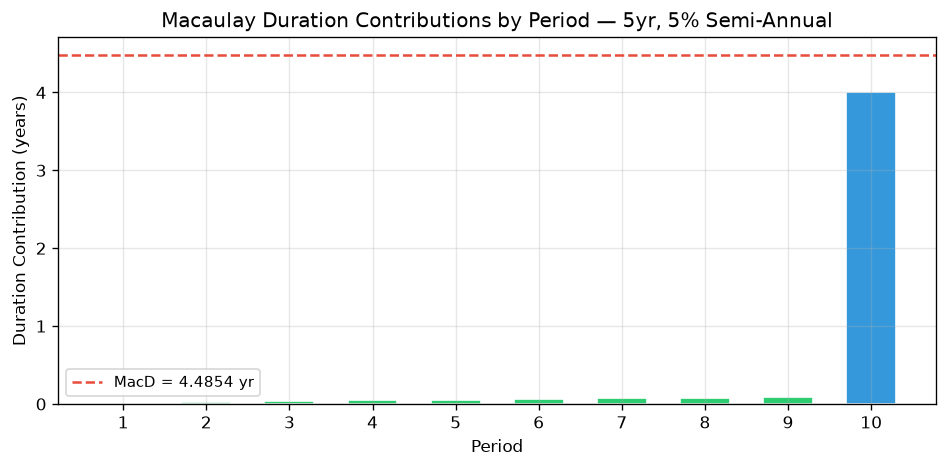

```python
def duration_contributions(bond: Bond, yield_rate: float):
    """Return per-period Macaulay Duration contributions."""
    r = yield_rate / bond.freq
    n = bond.periods
    t = np.arange(1, n + 1)
    cf = np.full(n, bond.coupon_payment)
    cf[-1] += bond.face_value
    pv = cf / (1 + r) ** t
    p = pv.sum()
    contribs = (t / bond.freq) * pv / p
    return t, cf, contribs


b3 = Bond(100, 0.05, 5.0, 2)
t, cf, contribs = duration_contributions(b3, 0.05)

fig, ax = figure(figsize=(8, 4))
colours = ["#2ecc71"] * (len(t) - 1) + ["#3498db"]
ax.bar(t, contribs, color=colours, edgecolor="white", width=0.6)
macd = contribs.sum()
ax.axhline(macd, color="#e74c3c", ls="--", lw=1.5, label=f"MacD = {macd:.4f} yr")
ax.set_xlabel("Period")
ax.set_ylabel("Duration Contribution (years)")
ax.set_title("Macaulay Duration Contributions by Period — 5yr, 5% Semi-Annual")
ax.legend(fontsize=9)
ax.set_xticks(t)
finish_plot(ax, grid=True)
plt.show()
```

## 2. Modified Duration

**Modified Duration** scales Macaulay Duration by the per-period discount factor to measure the *approximate percentage price sensitivity* to a small change in yield:

$$ ModD = \frac{MacD}{1 + y/m} $$

Interpretation: if $ModD = 2.75$, then a 1% (100 bps) increase in yield should cause roughly a 2.75% drop in price — before accounting for convexity.

We can verify Modified Duration numerically by taking the central difference of the price-yield function:

```python
def numerical_modd(bond: Bond, y: float, eps: float = 1e-6) -> float:
    """Modified Duration via central difference."""
    p = price(bond, y)
    return -(price(bond, y + eps) - price(bond, y - eps)) / (2 * eps * p)


b = Bond(100, 0.05, 5.0, 2)
y = 0.05
analytical = modified_duration(b, y)
numerical = numerical_modd(b, y)
print("Bond: 5yr, 5% semi-annual @ y=5%")
print(f"  Modified Duration (analytical): {analytical:.8f}")
print(f"  Modified Duration (numerical):  {numerical:.8f}")
print(f"  Match: {abs(analytical - numerical) < 1e-6}")

# Show ModD < MacD < T
macd = macaulay_duration(b, y)
print(f"\n  MacD = {macd:.6f}   ModD = {analytical:.6f}   T = {b.maturity}")
print(f"  MacD / (1 + y/m) = {macd / (1 + y / b.freq):.6f} = ModD")
print(f"  Ordering: ModD < MacD < Maturity? {analytical < macd < b.maturity}")
```

```
Bond: 5yr, 5% semi-annual @ y=5%
  Modified Duration (analytical): 4.37603197
  Modified Duration (numerical):  4.37603197
  Match: True

  MacD = 4.485433   ModD = 4.376032   T = 5.0
  MacD / (1 + y/m) = 4.376032 = ModD
  Ordering: ModD < MacD < Maturity? True
```

### Duration vs Yield

Duration changes with the yield level. At low yields, cash flows far in the future are discounted less, so they carry more weight — increasing duration. At high yields, near-term cash flows dominate, reducing duration.

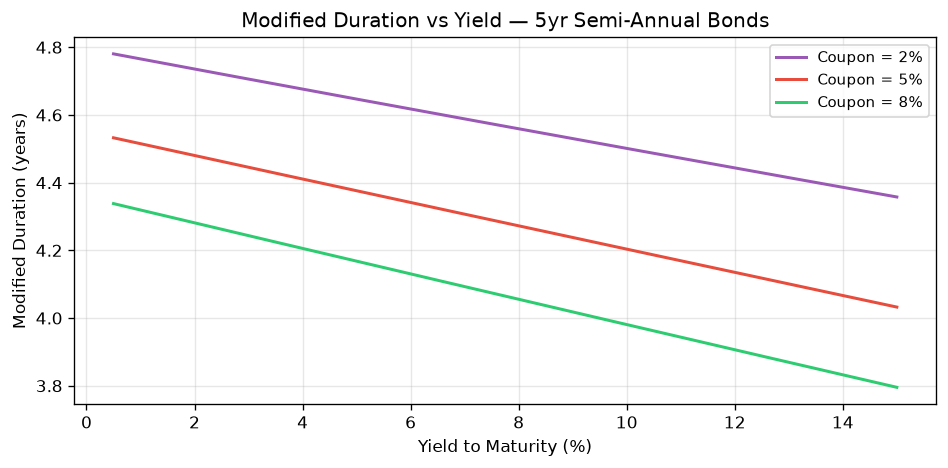

```python
yields = np.linspace(0.005, 0.15, 200)

fig, ax = figure(figsize=(8, 4))

for coupon, color in [(0.02, "#9b59b6"), (0.05, "#e74c3c"), (0.08, "#2ecc71")]:
    b = Bond(100, coupon, 5.0, 2)
    modds = [modified_duration(b, y) for y in yields]
    ax.plot(
        yields * 100,
        modds,
        label=f"Coupon = {coupon * 100:.0f}%",
        color=color,
        linewidth=1.8,
    )

ax.set_xlabel("Yield to Maturity (%)")
ax.set_ylabel("Modified Duration (years)")
ax.set_title("Modified Duration vs Yield — 5yr Semi-Annual Bonds")
ax.legend(fontsize=9)
finish_plot(ax, grid=True)
plt.show()
```

## 3. Convexity

The price-yield relationship is **convex** — the slope changes as yield changes. Convexity measures this curvature (the second derivative of price with respect to yield, normalised by price):

$$ Cx = \frac{1}{P} \, \frac{d^2 P}{dy^2} = \frac{1}{P} \sum_{t=1}^{n} \frac{t(t+1)}{m^2} \, \frac{CF_t}{(1 + y/m)^{t+2}} $$

For plain vanilla bonds, convexity is **always positive**: as yields fall, prices rise by increasingly more (per bp), and as yields rise, prices fall by increasingly less.

```python
# Zero-coupon bond convexity: analytical cross-check
zcb = Bond(100, 0.0, 5.0, 1)
y = 0.03
cx = convexity(zcb, y)
# For annual ZCB: Cx = T*(T+1) / (1+y)^2
expected = 5.0 * 6.0 / (1 + y) ** 2
print("Zero-coupon bond (annual, T=5, y=3%):")
print(f"  Convexity (analytical):   {cx:.10f}")
print(f"  Expected (T(T+1)/(1+y)^2): {expected:.10f}")
print(f"  Match: {abs(cx - expected) < 1e-10}\n")


# Numerical second-derivative cross-check
def numerical_convexity(bond: Bond, y: float, eps: float = 1e-4) -> float:
    p = price(bond, y)
    p_up = price(bond, y + eps)
    p_down = price(bond, y - eps)
    return (p_up - 2 * p + p_down) / (eps * eps * p)


b = Bond(100, 0.05, 5.0, 2)
cx_analytical = convexity(b, 0.05)
cx_numerical = numerical_convexity(b, 0.05)
print("Par bond (5yr, 5% semi @ y=5%):")
print(f"  Convexity (analytical): {cx_analytical:.6f}")
print(f"  Convexity (numerical):  {cx_numerical:.6f}")
print(f"  Match: {abs(cx_analytical - cx_numerical) < 1e-2}")
```

```
Zero-coupon bond (annual, T=5, y=3%):
  Convexity (analytical):   28.2778772740
  Expected (T(T+1)/(1+y)^2): 28.2778772740
  Match: True

Par bond (5yr, 5% semi @ y=5%):
  Convexity (analytical): 22.612322
  Convexity (numerical):  22.612323
  Match: True
```

### Convexity vs Yield

Like duration, convexity decreases as yields rise. Higher-coupon bonds have lower convexity because more of their value comes from near-term payments.

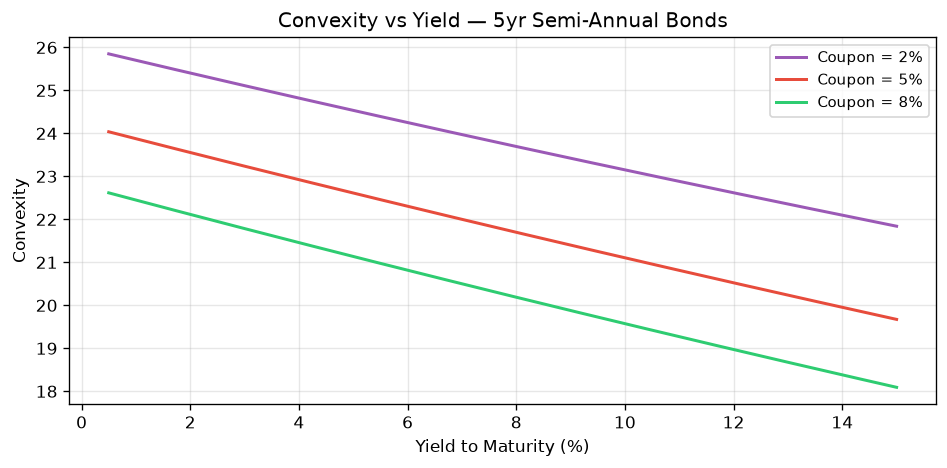

```python
fig, ax = figure(figsize=(8, 4))

for coupon, color in [(0.02, "#9b59b6"), (0.05, "#e74c3c"), (0.08, "#2ecc71")]:
    b = Bond(100, coupon, 5.0, 2)
    cxs = [convexity(b, y) for y in yields]
    ax.plot(
        yields * 100,
        cxs,
        label=f"Coupon = {coupon * 100:.0f}%",
        color=color,
        linewidth=1.8,
    )

ax.set_xlabel("Yield to Maturity (%)")
ax.set_ylabel("Convexity")
ax.set_title("Convexity vs Yield — 5yr Semi-Annual Bonds")
ax.legend(fontsize=9)
finish_plot(ax, grid=True)
plt.show()
```

## 4. Factors: Coupon & Maturity Effects

Both duration and convexity are systematically affected by the bond's coupon rate and time to maturity:

- **Higher coupon** → **lower** duration & convexity (more cash flow early)
- **Longer maturity** → **higher** duration & convexity (cash flows spread further out)

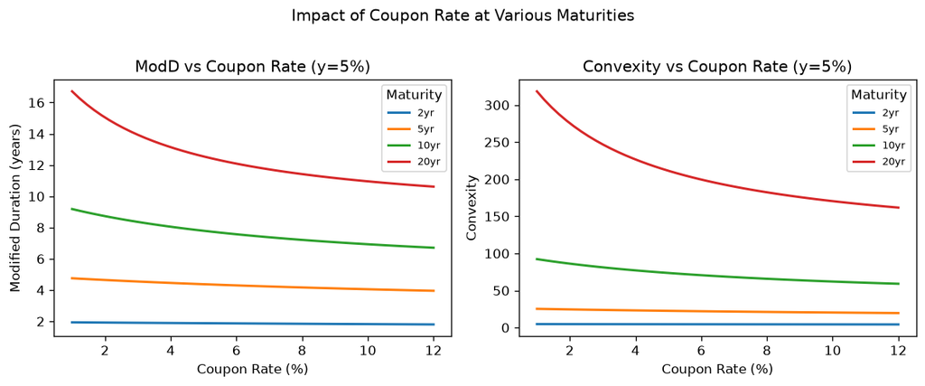

```python
fig, axes = subplots(1, 2, figsize=(10, 4))

coupons = np.linspace(0.01, 0.12, 50)
maturities = [2, 5, 10, 20]
y_fixed = 0.05

# Left: Duration vs Coupon
ax = axes[0]
for T in maturities:
    modds = []
    for c in coupons:
        b = Bond(100, c, float(T), 2)
        modds.append(modified_duration(b, y_fixed))
    ax.plot(coupons * 100, modds, label=f"{T}yr", linewidth=1.8)
ax.set_xlabel("Coupon Rate (%)")
ax.set_ylabel("Modified Duration (years)")
ax.set_title("ModD vs Coupon Rate (y=5%)")
ax.legend(fontsize=8, title="Maturity")

# Right: Convexity vs Coupon
ax = axes[1]
for T in maturities:
    cxs = []
    for c in coupons:
        b = Bond(100, c, float(T), 2)
        cxs.append(convexity(b, y_fixed))
    ax.plot(coupons * 100, cxs, label=f"{T}yr", linewidth=1.8)
ax.set_xlabel("Coupon Rate (%)")
ax.set_ylabel("Convexity")
ax.set_title("Convexity vs Coupon Rate (y=5%)")
ax.legend(fontsize=8, title="Maturity")

fig.suptitle("Impact of Coupon Rate at Various Maturities", y=1.02)
plt.tight_layout()
plt.show()
```

## 5. Shock Simulation — Taylor Series Expansion

Combining Modified Duration (first derivative) and Convexity (second derivative), we can approximate the price change for any yield shock $\Delta y$ using a second-order Taylor expansion:

$$ \Delta P \approx -ModD \cdot P \cdot \Delta y + \frac{1}{2} \, Cx \cdot P \cdot (\Delta y)^2 $$

The first term alone is the **duration-only (linear)** approximation. Adding the second term (the **convexity adjustment**) significantly improves accuracy, especially for large shocks.

```python
def taylor_first_order(bond: Bond, y: float, delta_y: float) -> float:
    """Price change using duration only (first-order Taylor)."""
    p = price(bond, y)
    modd = modified_duration(bond, y)
    return -modd * p * delta_y


def taylor_second_order(bond: Bond, y: float, delta_y: float) -> float:
    """Price change using duration + convexity (second-order Taylor)."""
    return price_shock(bond, y, delta_y)


b = Bond(100, 0.05, 5.0, 2)
y = 0.05
p0 = price(b, y)

print(f"Bond: 5yr, 5% semi-annual, y = 5%, P = ${p0:.4f}")
print()
print(f"{'Shock':>8} {'Exact Price':>13} {'1st-Order':>12} {'2nd-Order':>12}")
print(f"{'':>8} {'':>13} {'Taylor':>12} {'Taylor':>12}")
print("-" * 47)

for bp in [-200, -100, -50, -10, 10, 50, 100, 200]:
    delta = bp / 10000
    p_exact = price(b, y + delta)
    p1 = p0 + taylor_first_order(b, y, delta)
    p2 = shocked_price(b, y, delta)
    print(f"{bp:>+6}bp  {p_exact:>10.4f}  {p1:>10.4f}  {p2:>10.4f}")
```

```
Bond: 5yr, 5% semi-annual, y = 5%, P = $100.0000

   Shock   Exact Price    1st-Order    2nd-Order
                             Taylor       Taylor
-----------------------------------------------
  -200bp    109.2222    108.7521    109.2043
  -100bp    104.4913    104.3760    104.4891
   -50bp    102.2166    102.1880    102.2163
   -10bp    100.4387    100.4376    100.4387
   +10bp     99.5635     99.5624     99.5635
   +50bp     97.8400     97.8120     97.8402
  +100bp     95.7349     95.6240     95.7370
  +200bp     91.6834     91.2479     91.7002
```

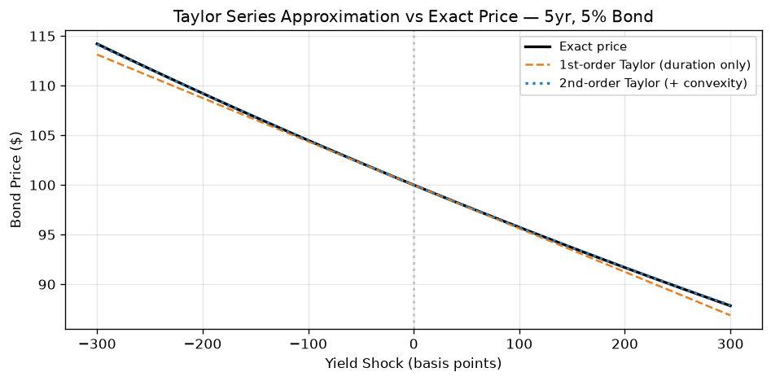

```python
# Compare approximation errors visually
deltas = np.linspace(-0.03, 0.03, 200)
p_exact = np.array([price(b, y + d) for d in deltas])
p_first = np.array([p0 + taylor_first_order(b, y, d) for d in deltas])
p_second = np.array([shocked_price(b, y, d) for d in deltas])

fig, ax = figure(figsize=(8, 4))
ax.plot(deltas * 10000, p_exact, "k-", label="Exact price", linewidth=2)
ax.plot(
    deltas * 10000,
    p_first,
    "--",
    color="#e67e22",
    label="1st-order Taylor (duration only)",
    linewidth=1.5,
)
ax.plot(
    deltas * 10000,
    p_second,
    ":",
    color="#2980b9",
    label="2nd-order Taylor (+ convexity)",
    linewidth=2,
)
ax.axvline(0, color="gray", ls=":", alpha=0.4)
ax.set_xlabel("Yield Shock (basis points)")
ax.set_ylabel("Bond Price ($)")
ax.set_title("Taylor Series Approximation vs Exact Price — 5yr, 5% Bond")
ax.legend(fontsize=8)
finish_plot(ax, grid=True)
plt.show()
```

### Convexity Asymmetry

Because convexity is positive, a yield **decrease** (rates fall) produces a **larger** price gain than the loss from an equal-sized yield increase. This is the **convexity bias** — the second-order term always adds to $\Delta P$ regardless of the direction of the shock.

```python
delta = 0.01
dp_up = price_shock(b, y, delta)
dp_down = price_shock(b, y, -delta)
p_up = shocked_price(b, y, delta)
p_down = shocked_price(b, y, -delta)

print(f"+{delta * 100:.0f}% shock: ΔP = {dp_up:>+8.4f},  P_new = ${p_up:<.4f}")
print(f"-{delta * 100:.0f}% shock: ΔP = {dp_down:>+8.4f}, P_new = ${p_down:<.4f}")
print(f"Gain from -1% > Loss from +1%? {abs(dp_down) > abs(dp_up)}")
print(
    f"Convexity term contribution: 0.5*Cx*P*(Δy)^2 = "
    f"{0.5 * convexity(b, y) * price(b, y) * delta**2:.6f}"
)
```

```
+1% shock: ΔP =  -4.2630,  P_new = $95.7370
-1% shock: ΔP =  +4.4891, P_new = $104.4891
Gain from -1% > Loss from +1%? True
Convexity term contribution: 0.5*Cx*P*(Δy)^2 = 0.113062
```

## 6. Convexity-Adjusted Price-Yield Curve

The tangent line at any point on the price-yield curve has slope $-ModD \cdot P$. The quadratic (convexity-adjusted) approximation follows the curve more closely.

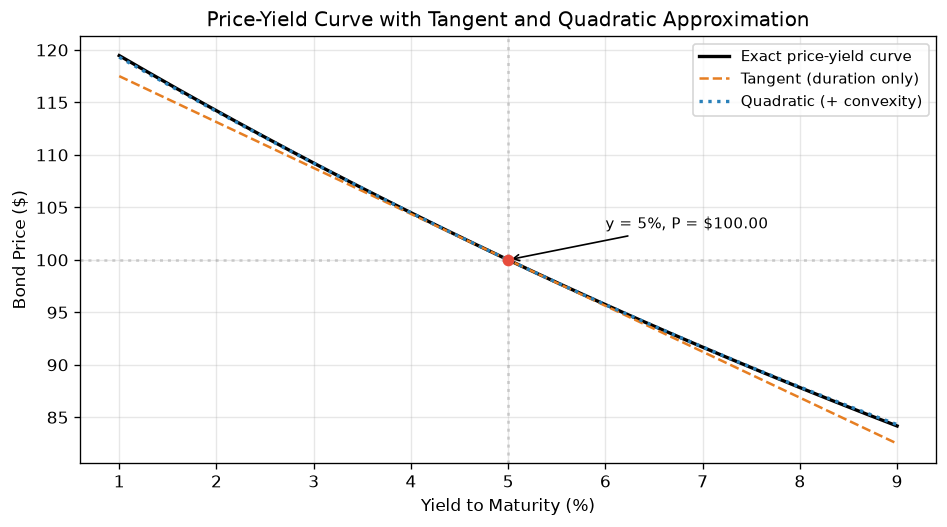

```python
y_center = 0.05
y_range = np.linspace(0.01, 0.09, 300)
p_curve = np.array([price(b, y) for y in y_range])

# Tangent line (first-order approximation at y_center)
p0 = price(b, y_center)
modd = modified_duration(b, y_center)
p_tangent = p0 + (-modd * p0) * (y_range - y_center)

# Quadratic approximation (second-order)
cx = convexity(b, y_center)
p_quad = (
    p0 + (-modd * p0) * (y_range - y_center) + 0.5 * cx * p0 * (y_range - y_center) ** 2
)

fig, ax = figure(figsize=(8, 4.5))
ax.plot(y_range * 100, p_curve, "k-", label="Exact price-yield curve", linewidth=2)
ax.plot(
    y_range * 100,
    p_tangent,
    "--",
    color="#e67e22",
    label="Tangent (duration only)",
    linewidth=1.5,
)
ax.plot(
    y_range * 100,
    p_quad,
    ":",
    color="#2980b9",
    label="Quadratic (+ convexity)",
    linewidth=2,
)
ax.axvline(y_center * 100, color="gray", ls=":", alpha=0.3)
ax.axhline(p0, color="gray", ls=":", alpha=0.3)
ax.plot(y_center * 100, p0, "o", color="#e74c3c", markersize=6, zorder=5)
ax.annotate(
    f"y = {y_center * 100:.0f}%, P = ${p0:.2f}",
    xy=(y_center * 100, p0),
    xytext=(y_center * 100 + 1, p0 + 3),
    arrowprops=dict(arrowstyle="->"),
    fontsize=9,
)
ax.set_xlabel("Yield to Maturity (%)")
ax.set_ylabel("Bond Price ($)")
ax.set_title("Price-Yield Curve with Tangent and Quadratic Approximation")
ax.legend(fontsize=8)
finish_plot(ax, grid=True)
plt.show()
```

## 7. Edge Cases & Stress Tests

Our risk measures handle corner cases robustly:

```python
print("Edge Case Tests:\n")

# 1. Zero-coupon bond at very low yield
zcb = Bond(100, 0.0, 10.0, 1)
y = 0.001
print(f"1. ZCB (T=10, y=0.1%): MacD = {macaulay_duration(zcb, y):.6f} (expected 10.0)")
print(f"   ModD = {modified_duration(zcb, y):.6f}, Cx = {convexity(zcb, y):.6f}")

# 2. Negative yield (rare but possible)
b = Bond(100, 0.02, 3.0, 1)
y = -0.005
print(f"2. Neg yield (-0.5%): MacD = {macaulay_duration(b, y):.6f}")
print(f"   ModD = {modified_duration(b, y):.6f}, Cx = {convexity(b, y):.6f}")

# 3. Single-period bond
b = Bond(100, 0.05, 0.5, 2)
y = 0.05
print(f"3. Single-period (6mo): MacD = {macaulay_duration(b, y):.6f}")
print(f"   ModD = {modified_duration(b, y):.6f}, Cx = {convexity(b, y):.8f}")

# 4. Yield = 0
b = Bond(100, 0.06, 3.0, 2)
print(
    f"4. Yield 0%: MacD = {macaulay_duration(b, 0.0):.6f}, "
    f"ModD = {modified_duration(b, 0.0):.6f}, Cx = {convexity(b, 0.0):.6f}"
)

# 5. High-coupon short-maturity (lowest risk)
b = Bond(100, 0.10, 1.0, 2)
print(
    f"5. High-coupon short: MacD = {macaulay_duration(b, 0.05):.6f}, "
    f"Cx = {convexity(b, 0.05):.6f}"
)
```

```
Edge Case Tests:

1. ZCB (T=10, y=0.1%): MacD = 10.000000 (expected 10.0)
   ModD = 9.990010, Cx = 109.780330
2. Neg yield (-0.5%): MacD = 2.943851
   ModD = 2.958644, Cx = 11.818365
3. Single-period (6mo): MacD = 0.500000
   ModD = 0.487805, Cx = 0.47590720
4. Yield 0%: MacD = 2.809322, ModD = 2.809322, Cx = 9.610169
5. High-coupon short: MacD = 0.976731, Cx = 1.383426
```

## 8. Systematic Verification

Cross-check that Macaulay Duration, Modified Duration, and Convexity are internally consistent across a range of bonds and yields.

```python
import itertools

test_bonds = [
    Bond(100, 0.05, 3.0, 2),
    Bond(100, 0.03, 5.0, 1),
    Bond(100, 0.0, 5.0, 1),
    Bond(100, 0.05, 5.0, 2),
    Bond(100, 0.08, 10.0, 2),
    Bond(100, 0.06, 2.0, 4),
]
test_yields = [0.02, 0.04, 0.05, 0.06, 0.10]

print(
    f"{'Bond':<38} {'Yield':>6} {'MacD':>8} {'ModD':>8} {'Cx':>10} {'ModD check':>10} {'Shock':>8}"
)
print("-" * 90)

for bond, y in itertools.product(test_bonds, test_yields):
    macd = macaulay_duration(bond, y)
    modd = modified_duration(bond, y)
    cx = convexity(bond, y)
    modd_check = macd / (1 + y / bond.freq)
    dp = price_shock(bond, y, 0.001)
    desc = f"F={bond.face_value} C={bond.coupon_rate * 100:.0f}% T={bond.maturity}yr m={bond.freq}"
    modd_ok = "✓" if abs(modd - modd_check) < 1e-12 else "✗"
    print(
        f"{desc:<38} {y * 100:>5.1f}% {macd:>8.4f} {modd:>8.4f} {cx:>10.4f} {modd_ok:>10} {dp:>+8.4f}"
    )
```

```
Bond                                    Yield     MacD     ModD         Cx ModD check    Shock
------------------------------------------------------------------------------------------
F=100 C=5% T=3.0yr m=2                   2.0%   2.8314   2.8034     9.5233          ✓  -0.3042
F=100 C=5% T=3.0yr m=2                   4.0%   2.8258   2.7704     9.3134          ✓  -0.2843
F=100 C=5% T=3.0yr m=2                   5.0%   2.8229   2.7541     9.2107          ✓  -0.2749
F=100 C=5% T=3.0yr m=2                   6.0%   2.8200   2.7379     9.1093          ✓  -0.2659
F=100 C=5% T=3.0yr m=2                  10.0%   2.8080   2.6743     8.7176          ✓  -0.2331
F=100 C=3% T=5.0yr m=1                   2.0%   4.7246   4.6319    26.7224          ✓  -0.4836
F=100 C=3% T=5.0yr m=1                   4.0%   4.7095   4.5284    25.5983          ✓  -0.4315
F=100 C=3% T=5.0yr m=1                   5.0%   4.7017   4.4779    25.0597          ✓  -0.4079
F=100 C=3% T=5.0yr m=1                   6.0%   4.6939   4.4282    24.5358          ✓  -0.3858
F=100 C=3% T=5.0yr m=1                  10.0%   4.6610   4.2373    22.5780          ✓  -0.3105
F=100 C=0% T=5.0yr m=1                   2.0%   5.0000   4.9020    28.8351          ✓  -0.4427
F=100 C=0% T=5.0yr m=1                   4.0%   5.0000   4.8077    27.7367          ✓  -0.3940
F=100 C=0% T=5.0yr m=1                   5.0%   5.0000   4.7619    27.2109          ✓  -0.3720
F=100 C=0% T=5.0yr m=1                   6.0%   5.0000   4.7170    26.6999          ✓  -0.3515
F=100 C=0% T=5.0yr m=1                  10.0%   5.0000   4.5455    24.7934          ✓  -0.2815
F=100 C=5% T=5.0yr m=2                   2.0%   4.5250   4.4802    23.5547          ✓  -0.5103
F=100 C=5% T=5.0yr m=2                   4.0%   4.4989   4.4107    22.9231          ✓  -0.4597
F=100 C=5% T=5.0yr m=2                   5.0%   4.4854   4.3760    22.6123          ✓  -0.4365
F=100 C=5% T=5.0yr m=2                   6.0%   4.4717   4.3414    22.3047          ✓  -0.4146
F=100 C=5% T=5.0yr m=2                  10.0%   4.4138   4.2036    21.1055          ✓  -0.3384
F=100 C=8% T=10.0yr m=2                  2.0%   7.6982   7.6219    71.5729          ✓  -1.1693
F=100 C=8% T=10.0yr m=2                  4.0%   7.4970   7.3500    67.7286          ✓  -0.9709
F=100 C=8% T=10.0yr m=2                  5.0%   7.3928   7.2125    65.8203          ✓  -0.8858
F=100 C=8% T=10.0yr m=2                  6.0%   7.2863   7.0740    63.9233          ✓  -0.8090
F=100 C=8% T=10.0yr m=2                 10.0%   6.8404   6.5146    56.4850          ✓  -0.5678
F=100 C=6% T=2.0yr m=4                   2.0%   1.9041   1.8946     4.1707          ✓  -0.2041
F=100 C=6% T=2.0yr m=4                   4.0%   1.9018   1.8830     4.1233          ✓  -0.1953
F=100 C=6% T=2.0yr m=4                   5.0%   1.9007   1.8772     4.0999          ✓  -0.1911
F=100 C=6% T=2.0yr m=4                   6.0%   1.8996   1.8715     4.0766          ✓  -0.1869
F=100 C=6% T=2.0yr m=4                  10.0%   1.8949   1.8487     3.9848          ✓  -0.1714
```

### 1bp Shock: Taylor vs Exact

For a very small shock (1 basis point), the second-order Taylor approximation should be virtually indistinguishable from exact repricing:

```python
print(f"{'Bond':<38} {'Yield':>6} {'Exact':>10} {'Taylor':>10} {'Error':>10}")
print("-" * 76)

for bond, y in itertools.product(test_bonds, test_yields):
    p0 = price(bond, y)
    delta = 0.0001
    p_exact = price(bond, y + delta)
    p_taylor = shocked_price(bond, y, delta)
    err = abs(p_taylor - p_exact)
    desc = f"F={bond.face_value} C={bond.coupon_rate * 100:.0f}% T={bond.maturity}yr m={bond.freq}"
    ok = "✓" if err < 1e-4 else "✗"
    print(
        f"{desc:<38} {y * 100:>5.1f}% {p_exact:>10.6f} {p_taylor:>10.6f} {err:>8.2e}  {ok}"
    )
```

```
Bond                                    Yield      Exact     Taylor      Error
----------------------------------------------------------------------------
F=100 C=5% T=3.0yr m=2                   2.0% 108.662749 108.662749 6.76e-10  ✓
F=100 C=5% T=3.0yr m=2                   4.0% 102.772240 102.772240 6.19e-10  ✓
F=100 C=5% T=3.0yr m=2                   5.0%  99.972464  99.972464 5.93e-10  ✓
F=100 C=5% T=3.0yr m=2                   6.0%  97.264772  97.264772 5.67e-10  ✓
F=100 C=5% T=3.0yr m=2                  10.0%  87.287424  87.287424 4.78e-10  ✓
F=100 C=3% T=5.0yr m=1                   2.0% 104.664971 104.664971 3.17e-09  ✓
F=100 C=3% T=5.0yr m=1                   4.0%  95.504922  95.504922 2.72e-09  ✓
F=100 C=3% T=5.0yr m=1                   5.0%  91.300157  91.300157 2.52e-09  ✓
F=100 C=3% T=5.0yr m=1                   6.0%  87.324234  87.324234 2.33e-09  ✓
F=100 C=3% T=5.0yr m=1                  10.0%  73.433372  73.433372 1.74e-09  ✓
F=100 C=0% T=5.0yr m=1                   2.0%  90.528695  90.528695 2.99e-09  ✓
F=100 C=0% T=5.0yr m=1                   4.0%  82.153206  82.153206 2.56e-09  ✓
F=100 C=0% T=5.0yr m=1                   5.0%  78.315317  78.315317 2.37e-09  ✓
F=100 C=0% T=5.0yr m=1                   6.0%  74.690579  74.690579 2.20e-09  ✓
F=100 C=0% T=5.0yr m=1                  10.0%  62.063916  62.063916 1.63e-09  ✓
F=100 C=5% T=5.0yr m=2                   2.0% 114.155803 114.155803 2.62e-09  ✓
F=100 C=5% T=5.0yr m=2                   4.0% 104.445217 104.445217 2.30e-09  ✓
F=100 C=5% T=5.0yr m=2                   5.0%  99.956251  99.956251 2.16e-09  ✓
F=100 C=5% T=5.0yr m=2                   6.0%  95.693347  95.693347 2.03e-09  ✓
F=100 C=5% T=5.0yr m=2                  10.0%  80.661750  80.661750 1.59e-09  ✓
F=100 C=8% T=10.0yr m=2                  2.0% 154.019232 154.019232 1.90e-08  ✓
F=100 C=8% T=10.0yr m=2                  4.0% 132.605375 132.605375 1.52e-08  ✓
F=100 C=8% T=10.0yr m=2                  5.0% 123.294794 123.294794 1.37e-08  ✓
F=100 C=8% T=10.0yr m=2                  6.0% 114.796247 114.796247 1.23e-08  ✓
F=100 C=8% T=10.0yr m=2                 10.0%  87.480787  87.480787 8.03e-09  ✓
F=100 C=6% T=2.0yr m=4                   2.0% 107.802533 107.802533 1.85e-10  ✓
F=100 C=6% T=2.0yr m=4                   4.0% 103.806291 103.806291 1.75e-10  ✓
F=100 C=6% T=2.0yr m=4                   5.0% 101.872906 101.872906 1.70e-10  ✓
F=100 C=6% T=2.0yr m=4                   6.0%  99.981287  99.981287 1.66e-10  ✓
F=100 C=6% T=2.0yr m=4                  10.0%  92.812704  92.812704 1.49e-10  ✓
```

## 9. Dollar Duration & DV01

Duration and convexity are *percentage* measures — they tell us by what **fraction** the price changes. In practice, portfolio managers need **dollar** measures to size hedges, compute P&L, and compare bonds with different face values.

| Measure | Definition | Interpretation |
| --- | --- | --- |
| Dollar Duration (DD) | $\text{ModD} \times P$ | Dollar price change per 1 unit yield change |
| DV01 (PVBP) | $DD / 10{,}000$ | Dollar price change per 1 basis point |
| Dollar Convexity (DC) | $\text{Cx} \times P$ | Dollar curvature of the price-yield curve |

```python
b = Bond(100, 0.05, 5.0, 2)
y = 0.05
p0 = price(b, y)

dd = dollar_duration(b, y)
d01 = dv01(b, y)
dc = dollar_convexity(b, y)

print(f"Bond: 5yr, 5% semi-annual @ y = {y * 100:.0f}%, P = ${p0:.4f}")
print(f"  Dollar Duration (DD):   {dd:.4f}")
print(f"  DV01 (PVBP):            {d01:.6f}")
print(f"  Dollar Convexity (DC):  {dc:.4f}")
print()
print(
    f"  Cross-check: DD = ModD × P = {modified_duration(b, y):.6f} × {p0:.4f} = {modified_duration(b, y) * p0:.4f}"
)
print(f"  Cross-check: DV01 = DD / 10,000 = {dd:.4f} / 10,000 = {dd / 10_000:.6f}")
print(
    f"  Cross-check: DC  = Cx × P = {convexity(b, y):.6f} × {p0:.4f} = {convexity(b, y) * p0:.4f}"
)
```

```
Bond: 5yr, 5% semi-annual @ y = 5%, P = $100.0000
  Dollar Duration (DD):   437.6032
  DV01 (PVBP):            0.043760
  Dollar Convexity (DC):  2261.2322

  Cross-check: DD = ModD × P = 4.376032 × 100.0000 = 437.6032
  Cross-check: DV01 = DD / 10,000 = 437.6032 / 10,000 = 0.043760
  Cross-check: DC  = Cx × P = 22.612322 × 100.0000 = 2261.2322
```

### DV01 Across the Test Universe

DV01 is the single most important number for hedging. Below we compute it for every bond-yield combination in our systematic test universe:

```python
print(f"{'Bond':<38} {'Yield':>6} {'Price':>10} {'DV01':>10} {'DD':>10} {'DC':>10}")
print("-" * 90)

for bond, y in itertools.product(test_bonds, test_yields):
    p = price(bond, y)
    dd_val = dollar_duration(bond, y)
    dv01_val = dv01(bond, y)
    dc_val = dollar_convexity(bond, y)
    desc = f"F={bond.face_value} C={bond.coupon_rate * 100:.0f}% T={bond.maturity}yr m={bond.freq}"
    print(
        f"{desc:<38} {y * 100:>5.1f}% {p:>10.4f} {dv01_val:>10.6f} {dd_val:>10.4f} {dc_val:>10.4f}"
    )
```

```
Bond                                    Yield      Price       DV01         DD         DC
------------------------------------------------------------------------------------------
F=100 C=5% T=3.0yr m=2                   2.0%   108.6932   0.030471   304.7114  1035.1158
F=100 C=5% T=3.0yr m=2                   4.0%   102.8007   0.028480   284.7974   957.4270
F=100 C=5% T=3.0yr m=2                   5.0%   100.0000   0.027541   275.4063   921.0679
F=100 C=5% T=3.0yr m=2                   6.0%    97.2914   0.026637   266.3709   886.2610
F=100 C=5% T=3.0yr m=2                  10.0%    87.3108   0.023349   233.4945   761.1427
F=100 C=3% T=5.0yr m=1                   2.0%   104.7135   0.048503   485.0261  2798.1987
F=100 C=3% T=5.0yr m=1                   4.0%    95.5482   0.043268   432.6760  2445.8747
F=100 C=3% T=5.0yr m=1                   5.0%    91.3410   0.040901   409.0117  2288.9768
F=100 C=3% T=5.0yr m=1                   6.0%    87.3629   0.038686   386.8583  2143.5208
F=100 C=3% T=5.0yr m=1                  10.0%    73.4645   0.031129   311.2895  1658.6823
F=100 C=0% T=5.0yr m=1                   2.0%    90.5731   0.044399   443.9857  2611.6805
F=100 C=0% T=5.0yr m=1                   4.0%    82.1927   0.039516   395.1573  2279.7534
F=100 C=0% T=5.0yr m=1                   5.0%    78.3526   0.037311   373.1077  2132.0440
F=100 C=0% T=5.0yr m=1                   6.0%    74.7258   0.035248   352.4803  1995.1713
F=100 C=0% T=5.0yr m=1                  10.0%    62.0921   0.028224   282.2370  1539.4744
F=100 C=5% T=5.0yr m=2                   2.0%   114.2070   0.051167   511.6703  2690.1139
F=100 C=5% T=5.0yr m=2                   4.0%   104.4913   0.046088   460.8787  2395.2691
F=100 C=5% T=5.0yr m=2                   5.0%   100.0000   0.043760   437.6032  2261.2322
F=100 C=5% T=5.0yr m=2                   6.0%    95.7349   0.041563   415.6269  2135.3409
F=100 C=5% T=5.0yr m=2                  10.0%    80.6957   0.033921   339.2132  1703.1225
F=100 C=8% T=10.0yr m=2                  2.0%   154.1367   0.117482  1174.8201 11032.0114
F=100 C=8% T=10.0yr m=2                  4.0%   132.7029   0.097537   975.3675  8987.7752
```

```
F=100 C=8% T=10.0yr m=2                  5.0%   123.3837   0.088990   889.9012  8121.1496
F=100 C=8% T=10.0yr m=2                  6.0%   114.8775   0.081265   812.6486  7343.3526
F=100 C=8% T=10.0yr m=2                 10.0%    87.5378   0.057028   570.2769  4944.5752
F=100 C=6% T=2.0yr m=4                   2.0%   107.8230   0.020428   204.2801   449.7003
F=100 C=6% T=2.0yr m=4                   4.0%   103.8258   0.019550   195.5039   428.1089
F=100 C=6% T=2.0yr m=4                   5.0%   101.8920   0.019127   191.2749   417.7443
F=100 C=6% T=2.0yr m=4                   6.0%   100.0000   0.018715   187.1481   407.6560
F=100 C=6% T=2.0yr m=4                  10.0%    92.8299   0.017161   171.6103   369.9088
```

### DV01 Numerical Cross-Check

```python
print(f"{'Bond':<38} {'Yield':>6} {'DV01 (anal)':>12} {'DV01 (num)':>12} {'Error':>10}")
print("-" * 84)

for bond, y in itertools.product(test_bonds, test_yields):
    dv01_ana = dv01(bond, y)
    # Numerical: actual price change for +1bp
    dv01_num = abs(price(bond, y + 0.0001) - price(bond, y))
    err = abs(dv01_ana - dv01_num)
    desc = f"F={bond.face_value} C={bond.coupon_rate * 100:.0f}% T={bond.maturity}yr m={bond.freq}"
    ok = "✓" if err < 1e-6 else "✗"
    print(
        f"{desc:<38} {y * 100:>5.1f}% {dv01_ana:>12.8f} {dv01_num:>12.8f} {err:>8.2e}  {ok}"
    )
```

```
Bond                                    Yield  DV01 (anal)   DV01 (num)      Error
------------------------------------------------------------------------------------
F=100 C=5% T=3.0yr m=2                   2.0%   0.03047114   0.03046597 5.17e-06  ✗
F=100 C=5% T=3.0yr m=2                   4.0%   0.02847974   0.02847496 4.79e-06  ✗
F=100 C=5% T=3.0yr m=2                   5.0%   0.02754063   0.02753602 4.60e-06  ✗
F=100 C=5% T=3.0yr m=2                   6.0%   0.02663709   0.02663266 4.43e-06  ✗
F=100 C=5% T=3.0yr m=2                  10.0%   0.02334945   0.02334564 3.81e-06  ✗
F=100 C=3% T=5.0yr m=1                   2.0%   0.04850261   0.04848862 1.40e-05  ✗
F=100 C=3% T=5.0yr m=1                   4.0%   0.04326760   0.04325537 1.22e-05  ✗
F=100 C=3% T=5.0yr m=1                   5.0%   0.04090117   0.04088973 1.14e-05  ✗
F=100 C=3% T=5.0yr m=1                   6.0%   0.03868583   0.03867512 1.07e-05  ✗
F=100 C=3% T=5.0yr m=1                  10.0%   0.03112895   0.03112066 8.29e-06  ✗
F=100 C=0% T=5.0yr m=1                   2.0%   0.04439857   0.04438551 1.31e-05  ✗
F=100 C=0% T=5.0yr m=1                   4.0%   0.03951573   0.03950433 1.14e-05  ✗
F=100 C=0% T=5.0yr m=1                   5.0%   0.03731077   0.03730011 1.07e-05  ✗
F=100 C=0% T=5.0yr m=1                   6.0%   0.03524803   0.03523805 9.97e-06  ✗
F=100 C=0% T=5.0yr m=1                  10.0%   0.02822370   0.02821600 7.70e-06  ✗
F=100 C=5% T=5.0yr m=2                   2.0%   0.05116703   0.05115358 1.34e-05  ✗
F=100 C=5% T=5.0yr m=2                   4.0%   0.04608787   0.04607589 1.20e-05  ✗
F=100 C=5% T=5.0yr m=2                   5.0%   0.04376032   0.04374902 1.13e-05  ✗
F=100 C=5% T=5.0yr m=2                   6.0%   0.04156269   0.04155201 1.07e-05  ✗
F=100 C=5% T=5.0yr m=2                  10.0%   0.03392132   0.03391281 8.51e-06  ✗
F=100 C=8% T=10.0yr m=2                  2.0%   0.11748201   0.11742687 5.51e-05  ✗
F=100 C=8% T=10.0yr m=2                  4.0%   0.09753675   0.09749183 4.49e-05  ✗
F=100 C=8% T=10.0yr m=2                  5.0%   0.08899012   0.08894953 4.06e-05  ✗
F=100 C=8% T=10.0yr m=2                  6.0%   0.08126486   0.08122815 3.67e-05  ✗
F=100 C=8% T=10.0yr m=2                 10.0%   0.05702769   0.05700297 2.47e-05  ✗
F=100 C=6% T=2.0yr m=4                   2.0%   0.02042801   0.02042576 2.25e-06  ✗
F=100 C=6% T=2.0yr m=4                   4.0%   0.01955039   0.01954825 2.14e-06  ✗
F=100 C=6% T=2.0yr m=4                   5.0%   0.01912749   0.01912540 2.09e-06  ✗
F=100 C=6% T=2.0yr m=4                   6.0%   0.01871481   0.01871277 2.04e-06  ✗
F=100 C=6% T=2.0yr m=4                  10.0%   0.01716103   0.01715918 1.85e-06  ✗
```

## 10. Key Rate Duration

Macaulay and Modified Duration assume a **parallel** shift in the yield curve — all rates move by the same amount. In reality, the curve can twist, steepen, or flatten.

**Key Rate Duration (KRD)** measures sensitivity to bumps at specific maturity points on the curve. For a flat curve, the sum of all KRDs equals Modified Duration.

We use a numerical bumping approach: bump the yield at one key rate tenor, interpolate the bump to each cash flow's time, reprice, and compute the partial duration.

```python
# KRD profile for a 5yr, 5% semi-annual bond
b = Bond(100, 0.05, 5.0, 2)
y = 0.05
krd = key_rate_durations(b, y)
modd = modified_duration(b, y)

print(f"Bond: 5yr, 5% semi-annual @ y = {y * 100:.0f}%")
print(f"Modified Duration: {modd:.6f}\n")
print(f"{'Tenor':>8} {'KRD':>10}")
print("-" * 20)
for tenor, krd_val in krd.items():
    print(f"{tenor:>7.1f}y {krd_val:>10.6f}")
print(f"{'Sum':>8} {sum(krd.values()):>10.6f}")
print(f"{'ModD':>8} {modd:>10.6f}")
print(f"\nΣKRD ≈ ModD? {abs(sum(krd.values()) - modd) < 0.01}")
```

```
Bond: 5yr, 5% semi-annual @ y = 5%
Modified Duration: 4.376032

   Tenor        KRD
--------------------
    0.5y   0.011897
    1.0y   0.040199
    2.0y   0.088118
    3.0y   0.205884
    5.0y   4.028831
     Sum   4.374929
    ModD   4.376032

ΣKRD ≈ ModD? True
```

### Visualising KRD Profiles

We compare KRD profiles for bonds with different maturities. Longer bonds have more weight at longer tenors:

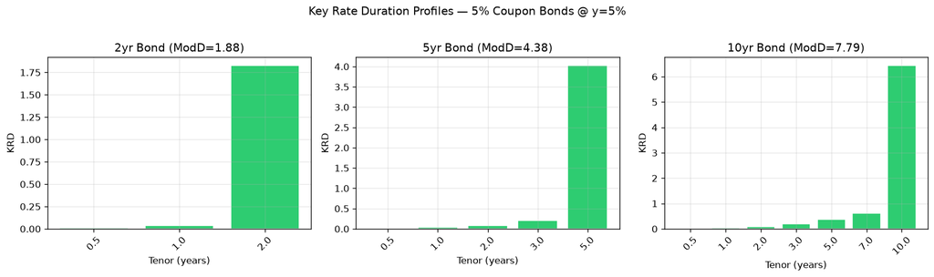

```python
krd_bonds = [
    (Bond(100, 0.05, 2.0, 2), "2yr"),
    (Bond(100, 0.05, 5.0, 2), "5yr"),
    (Bond(100, 0.05, 10.0, 2), "10yr"),
]
y = 0.05

fig, axes = subplots(nrows=1, ncols=3, figsize=(14, 4))

for ax, (bond, label) in zip(axes, krd_bonds):
    krd = key_rate_durations(bond, y)
    tenors = list(krd.keys())
    values = list(krd.values())
    colours = ["#2ecc71" if v > 0.01 else "#bdc3c7" for v in values]
    ax.bar([str(t) for t in tenors], values, color=colours, edgecolor="white")
    ax.set_title(f"{label} Bond (ModD={modified_duration(bond, y):.2f})")
    ax.set_xlabel("Tenor (years)")
    ax.set_ylabel("KRD")
    ax.tick_params(axis="x", rotation=45)
    finish_plot(ax, grid=True, legend=False)

plt.suptitle("Key Rate Duration Profiles — 5% Coupon Bonds @ y=5%", fontsize=12, y=1.02)
plt.tight_layout()
plt.show()
```

### KRD for Zero-Coupon Bond

For a zero-coupon bond, all sensitivity should be concentrated at the maturity point — there are no interim cash flows to distribute across tenors:

```python
zcb = Bond(100, 0.0, 5.0, 1)
y = 0.03
krd = key_rate_durations(zcb, y)
modd = modified_duration(zcb, y)

print(f"Zero-coupon bond (T=5yr, annual) @ y = {y * 100:.0f}%")
print(f"Modified Duration: {modd:.6f}\n")
for tenor, krd_val in krd.items():
    pct = krd_val / sum(krd.values()) * 100 if sum(krd.values()) > 0 else 0
    print(f"  {tenor:.1f}y: KRD = {krd_val:.6f}  ({pct:.1f}%)")
print(
    f"\nKRD at maturity / Total = {krd[5.0] / sum(krd.values()) * 100:.1f}% (expected ~100%)"
)
```

```
Zero-coupon bond (T=5yr, annual) @ y = 3%
Modified Duration: 4.854369

  0.5y: KRD = 0.000000  (0.0%)
  1.0y: KRD = 0.000000  (0.0%)
  2.0y: KRD = 0.000000  (0.0%)
  3.0y: KRD = 0.000000  (0.0%)
  5.0y: KRD = 4.852955  (100.0%)

KRD at maturity / Total = 100.0% (expected ~100%)
```